[figure not shown]

## Course: Estadística Para el Análisis Político II Semestre 2017-II

### Prof. José Manuel Magallanes, PhD

## **Análisis Multivariado**

## Modelamiento y Técnicas Predictivas (Datos de corte tranversal)

Carguemos la data:

```r
folder='data'
fileName='idh_elec.csv'
fileToRead=file.path(folder,fileName)
idh_elec=read.csv(fileToRead,strip.white = T,
                  stringsAsFactors = F)
```

Como antes revisemos que TIPO de data tenemos:

```r
str(idh_elec)
```

```
## 'data.frame':    1834 obs. of  14 variables:
##  $ ubiReg    : int  10000 10000 10000 10000 10000 10000 10000 10000 10000 10000 ...
##  $ ubiProv   : int  10200 10200 10200 10200 10200 10200 10300 10300 10300 10300 ...
##  $ ubiDis    : int  10202 10201 10203 10204 10205 10206 10302 10303 10304 10305 ...
##  $ depa      : chr  "AMAZONAS" "AMAZONAS" "AMAZONAS" "AMAZONAS" ...
##  $ prov      : chr  "BAGUA" "BAGUA" "BAGUA" "BAGUA" ...
##  $ dist      : chr  "ARAMANGO" "BAGUA" "COPALLIN" "EL PARCO" ...
##  $ pobla     : int  11587 26067 6501 1443 23820 8020 349 282 922 883 ...
##  $ idh       : num  0.311 0.479 0.366 0.408 0.236 ...
##  $ esperanza : num  76.8 74.7 78 77.4 77.4 ...
##  $ secundaria: num  21.6 59.3 38.7 44.1 16 ...
##  $ tiempoedu : num  5.38 8.33 5.77 6.24 5.78 8.33 5.76 6.75 4.83 5.04 ...
##  $ percapitaf: num  405 662 452 551 209 ...
##  $ PPK       : int  1823 4949 1490 604 6282 2342 135 92 234 283 ...
##  $ FP        : int  3072 5809 1321 400 2059 2765 118 162 189 155 ...
```

La data tiene los componentes del IDH calculados por distrito el año 2012. Así mismo, tenemos los votos para PPK y KEIKO durante la segunda vuelta del 2016. Veamos qué podemos preguntarnos con técnicas multivariadas.

```r
idh_elec$ganappk=as.factor(ifelse(idh_elec$PPK>idh_elec$FP,1,0))
levels(idh_elec$ganappk)=c('Keiko','PPK')
```

## Buscando explicaciones

Si quisieramos saber cómo están relacionados los resultados electorales con el idh, necesitamos hacer una regresión. Primero, creemos un subconjunto:

```r
test=idh_elec[,c('ganappk','esperanza','secundaria','tiempoedu','percapitaf')]
aggregate(cbind(esperanza,secundaria,tiempoedu,percapitaf) ~ ganappk, data=test,FUN=mean)
```

```
##   ganappk esperanza secundaria tiempoedu percapitaf
## 1   Keiko  73.26403   43.87029  6.775873   386.2901
## 2     PPK  71.96195   47.73951  6.882518   399.6531
```

Exploremos esos grupos con más detalle:

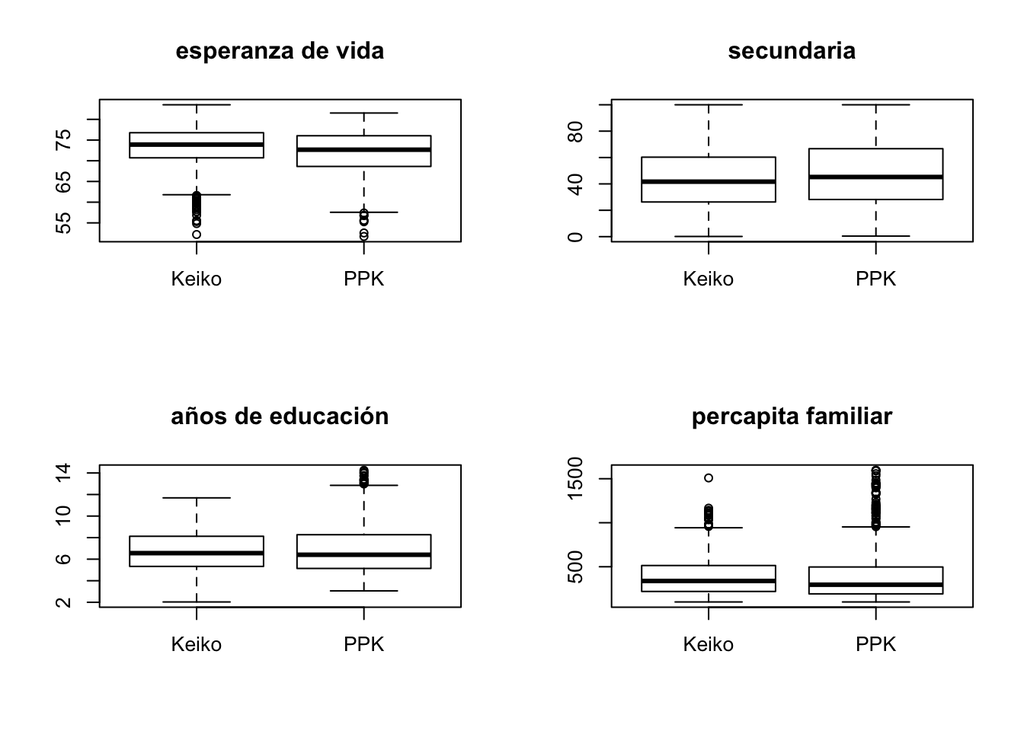

```r
par(mfrow=c(2,2))
boxplot(esperanza ~ ganappk, data=test,main='esperanza de vida')
boxplot(secundaria ~ ganappk, data=test,main='secundaria')
boxplot(tiempoedu ~ ganappk, data=test,main='años de educación')
boxplot(percapitaf ~ ganappk, data=test,main='percapita familiar')
```

Aqui proponemos un modelo:

```r
modeloDico <- glm(ganappk ~ .,
                 data = test,
                 family = "binomial")

summary(modeloDico)
```

```
##
## Call:
## glm(formula = ganappk ~ ., family = "binomial", data = test)
##
## Deviance Residuals:
##    Min      1Q  Median      3Q     Max
## -1.666  -1.080  -0.904   1.199   1.655
##
## Coefficients:
##               Estimate Std. Error z value Pr(>|z|)
## (Intercept)  3.7432039  0.6927416   5.403 6.54e-08 ***
## esperanza   -0.0558598  0.0096419  -5.793 6.90e-09 ***
## secundaria   0.0140213  0.0032690   4.289 1.79e-05 ***
## tiempoedu   -0.1062897  0.0496310  -2.142   0.0322 *
## percapitaf   0.0005724  0.0003128   1.830   0.0673 .
## ---
## Signif. codes:  0 '***' 0.001 '**' 0.01 '*' 0.05 '.' 0.1 ' ' 1
##
## (Dispersion parameter for binomial family taken to be 1)
##
##     Null deviance: 2528.8  on 1833  degrees of freedom
## Residual deviance: 2473.6  on 1829  degrees of freedom
## AIC: 2483.6
##
## Number of Fisher Scoring iterations: 4
```

Los valores negativos indican que el aumento de esa variable disminuye la probabilidad de ganar para PPK, los positivos lo contrario (siempre que el p-valor sea muy pequeño). Otra manera de leerlo:

```r
exp(coef(modeloDico))
```

```
## (Intercept)   esperanza  secundaria   tiempoedu  percapitaf
##  42.2330861   0.9456717   1.0141201   0.8991641   1.0005726
```

Lo anterior ‘modelaba’ la respuesta dicotómica *gana ppk*, pero si tuvieramos una variable de conteo?

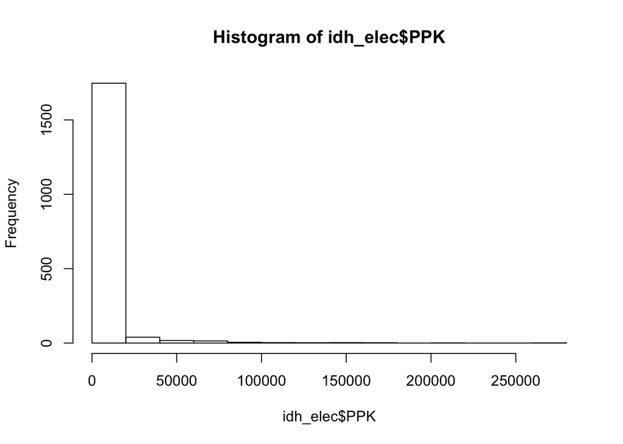

```r
hist(idh_elec$PPK) # votos de PPK
```

Preparemos ese subconjunto:

```r
test2=idh_elec[,c('PPK','esperanza','secundaria','tiempoedu','percapitaf')]
```

Calculemos la media y la desviacion típica de la variable de conteos:

```r
c(mean(test2$PPK),sd(test2$PPK))
```

```
## [1]  4562.671 15761.576
```

Se nota tanto por los estadisticos como por las gráficas que hay mucha dispersión. Intentemos modelar los conteos con una regresión de Poisson:

```r
modelConteo = glm(PPK ~ ., data = test2, family = poisson)
summary(modelConteo)
```

```
##
## Call:
## glm(formula = PPK ~ ., family = poisson, data = test2)
##
## Deviance Residuals:
##     Min       1Q   Median       3Q      Max
## -405.07   -50.90   -20.30    15.34   926.39
##
## Coefficients:
##              Estimate Std. Error z value Pr(>|z|)
## (Intercept) 2.414e+00  6.675e-03   361.7   <2e-16 ***
## esperanza   2.979e-02  9.320e-05   319.6   <2e-16 ***
## secundaria  4.744e-03  2.879e-05   164.8   <2e-16 ***
## tiempoedu   3.721e-01  3.817e-04   974.8   <2e-16 ***
## percapitaf  8.226e-04  1.800e-06   457.1   <2e-16 ***
## ---
## Signif. codes:  0 '***' 0.001 '**' 0.01 '*' 0.05 '.' 0.1 ' ' 1
##
## (Dispersion parameter for poisson family taken to be 1)
##
##     Null deviance: 27321983  on 1833  degrees of freedom
## Residual deviance: 12278584  on 1829  degrees of freedom
## AIC: 12294730
##
## Number of Fisher Scoring iterations: 6
```

Veamos si este tipo de modelo explica los datos:

```r
1 - pchisq(summary(modelConteo)$deviance,
           summary(modelConteo)$df.residual)
```

```
## [1] 0
```

Acabamos de hipotetizar con el test anterior que la data si está bien explicada por el modelo, pero el resultado, al ser menor que 0.05, sugiere que NO es así.

La alternativa en esta situación es:

```r
library(MASS)
modelConteo2=glm.nb(PPK ~ ., data= test2)
summary(modelConteo2)
```

```
##
## Call:
## glm.nb(formula = PPK ~ ., data = test2, init.theta = 0.7938633075,
##     link = log)
##
## Deviance Residuals:
##     Min       1Q   Median       3Q      Max
## -3.3756  -1.1384  -0.5549   0.2034   4.2320
##
## Coefficients:
##               Estimate Std. Error z value Pr(>|z|)
## (Intercept)  6.0927490  0.3757234  16.216  < 2e-16 ***
## esperanza    0.0013744  0.0052232   0.263    0.792
## secundaria   0.0072769  0.0017782   4.092 4.27e-05 ***
## tiempoedu   -0.0367809  0.0271266  -1.356    0.175
## percapitaf   0.0036571  0.0001719  21.277  < 2e-16 ***
## ---
## Signif. codes:  0 '***' 0.001 '**' 0.01 '*' 0.05 '.' 0.1 ' ' 1
##
## (Dispersion parameter for Negative Binomial(0.7939) family taken to be 1)
##
##     Null deviance: 4265.3  on 1833  degrees of freedom
## Residual deviance: 2178.2  on 1829  degrees of freedom
## AIC: 31887
##
## Number of Fisher Scoring iterations: 1
##
##
##               Theta:  0.7939
##           Std. Err.:  0.0226
##
##  2 x log-likelihood:  -31874.9470
```

```r
1 - pchisq(summary(modelConteo2)$deviance,
           summary(modelConteo2)$df.residual)
```

```
## [1] 2.472499e-08
```

Como el valor anterior nos sigue diciendo que el modelo no es el adecuado, debemos prestarle atención a los valores pequeños

```r
paste(sum(test2$PPK<200)/length(test2$PPK),max(test2$PPK))
```

```
## [1] "0.110687022900763 264607"
```

Probemos entonces con un modelo de ‘ceros-excesivos’:

```r
library(pscl)
modelConteo3=zeroinfl(PPK ~ ., data = test2,dist = "negbin")
summary(modelConteo3)
```

```
##
## Call:
## zeroinfl(formula = PPK ~ ., data = test2, dist = "negbin")
##
## Pearson residuals:
##     Min      1Q  Median      3Q     Max
## -0.8906 -0.7143 -0.4462  0.2192 12.4609
##
## Count model coefficients (negbin with log link):
##               Estimate Std. Error z value Pr(>|z|)
## (Intercept)  6.0928410  0.4191772  14.535  < 2e-16 ***
## esperanza    0.0013773  0.0057983   0.238 0.812245
## secundaria   0.0072804  0.0021314   3.416 0.000636 ***
## tiempoedu   -0.0368587  0.0314532  -1.172 0.241253
## percapitaf   0.0036573  0.0002094  17.469  < 2e-16 ***
## Log(theta)  -0.2308651  0.0287332  -8.035 9.37e-16 ***
##
## Zero-inflation model coefficients (binomial with logit link):
##               Estimate Std. Error z value Pr(>|z|)
## (Intercept) -1.946e+01  1.480e+03  -0.013    0.990
## esperanza    8.849e-02  2.103e+01   0.004    0.997
## secundaria   5.229e-02  4.390e+00   0.012    0.990
## tiempoedu   -7.938e-01  8.069e+01  -0.010    0.992
## percapitaf  -3.243e-03  8.458e-01  -0.004    0.997
## ---
## Signif. codes:  0 '***' 0.001 '**' 0.01 '*' 0.05 '.' 0.1 ' ' 1
##
## Theta = 0.7938
## Number of iterations in BFGS optimization: 24
## Log-likelihood: -1.594e+04 on 11 Df
```

Para que el modelo aporte a la explicación, necesitamos que este test sea significativo:

```r
mnull <- update(modelConteo3, . ~ 1)
pchisq(2 * (logLik(modelConteo3) - logLik(mnull)), df = ncol(test2)-1, lower.tail = FALSE)
```

```
## 'log Lik.' 0 (df=11)
```

Parece que hemos mejorado al Poisson:

```r
vuong(modelConteo, modelConteo3)
```

```
## NA or numerical zeros or ones encountered in fitted probabilities
## dropping these 887 cases, but proceed with caution
## Vuong Non-Nested Hypothesis Test-Statistic:
## (test-statistic is asymptotically distributed N(0,1) under the
##  null that the models are indistinguishible)
## -------------------------------------------------------------
##               Vuong z-statistic             H_A    p-value
## Raw                   -34.43673 model2 > model1 < 2.22e-16
## AIC-corrected         -34.43595 model2 > model1 < 2.22e-16
## BIC-corrected         -34.43407 model2 > model1 < 2.22e-16
```

Ahora, si dividiésemos el conteo de votos entre la población, la razón encontrada nos da una *medición*:

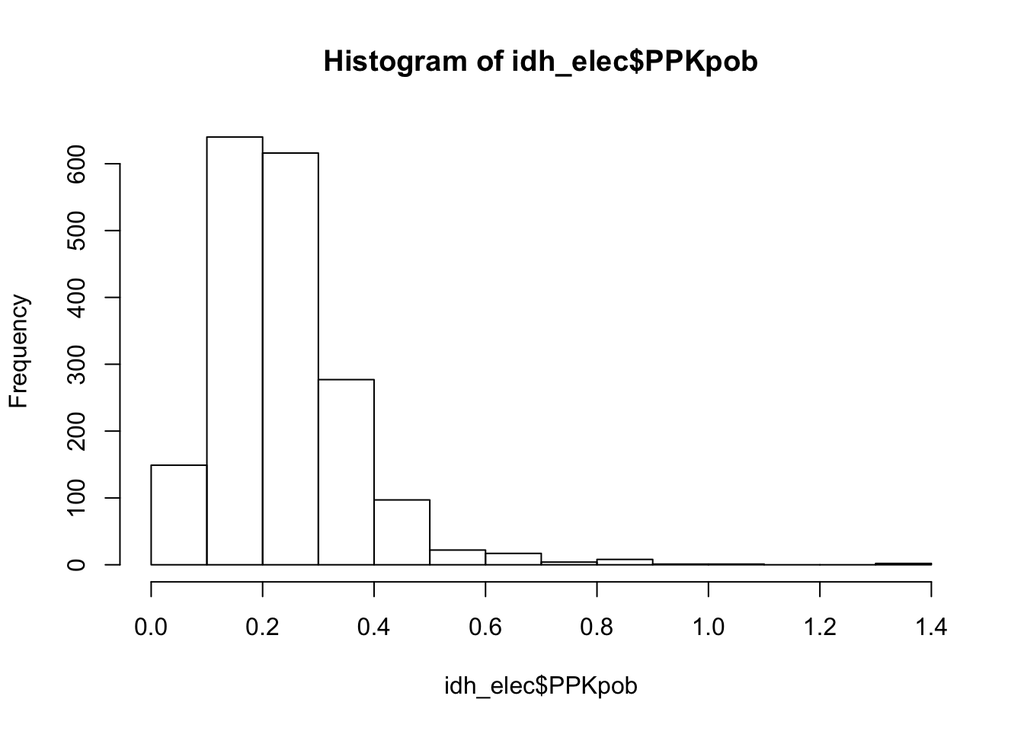

```r
idh_elec$PPKpob=idh_elec$PPK/idh_elec$pobla
hist(idh_elec$PPKpob)
```

Separemos este subconjunto:

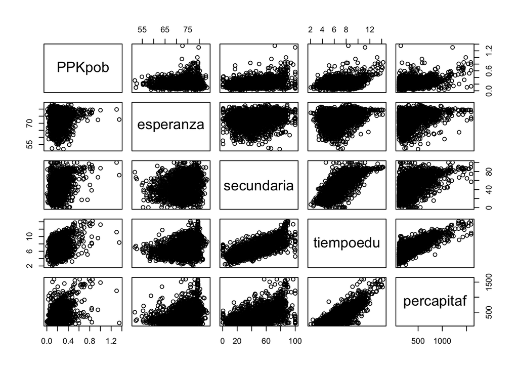

```r
test3=idh_elec[,c('PPKpob','esperanza','secundaria','tiempoedu','percapitaf')]
plot(test3) #aparecen relaciones lineales?
```

La mayor forma acampanada, nos anima a pensar en una regresión Gauss:

```r
modeloMedida <- glm(PPKpob ~ .,
                 data = test3,
                 family = gaussian)

summary(modeloMedida)
```

```
##
## Call:
## glm(formula = PPKpob ~ ., family = gaussian, data = test3)
##
## Deviance Residuals:
##      Min        1Q    Median        3Q       Max
## -0.32784  -0.07237  -0.01227   0.05825   1.12578
##
## Coefficients:
##               Estimate Std. Error t value Pr(>|t|)
## (Intercept)  0.1653338  0.0380283   4.348 1.45e-05 ***
## esperanza   -0.0001776  0.0005287  -0.336   0.7370
## secundaria   0.0014663  0.0001800   8.147 6.83e-16 ***
## tiempoedu   -0.0066484  0.0027456  -2.421   0.0156 *
## percapitaf   0.0001611  0.0000174   9.258  < 2e-16 ***
## ---
## Signif. codes:  0 '***' 0.001 '**' 0.01 '*' 0.05 '.' 0.1 ' ' 1
##
## (Dispersion parameter for gaussian family taken to be 0.01291111)
##
##     Null deviance: 28.983  on 1833  degrees of freedom
## Residual deviance: 23.614  on 1829  degrees of freedom
## AIC: -2765.6
##
## Number of Fisher Scoring iterations: 2
```

Parece que fue una buena elección:

```r
1 - pchisq(summary(modeloMedida)$deviance,
           summary(modeloMedida)$df.residual)
```

```
## [1] 1
```

Sin embargo, dada la distribución de la densidad, el comportamiento de los residuos no se ajustará bien (se esperaba normalidad):

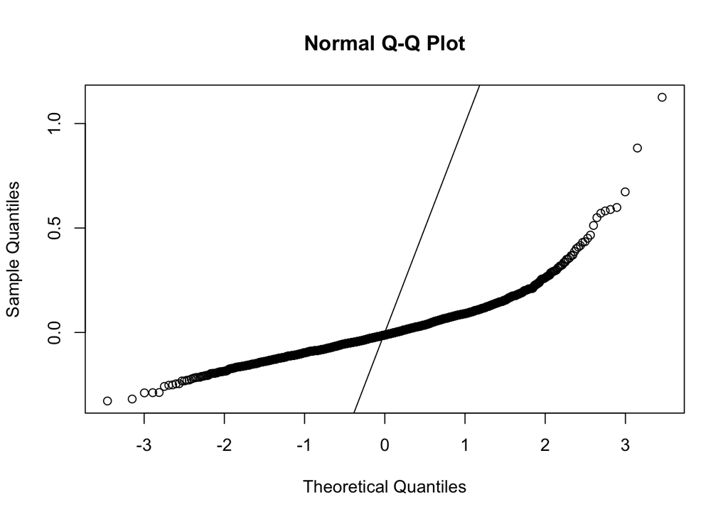

```r
qqnorm(residuals(modeloMedida))
abline(a=0,b=1)
```

Calculemos ahora las diferencias entre ambos, y veamos cómo se distribuyem éstas:

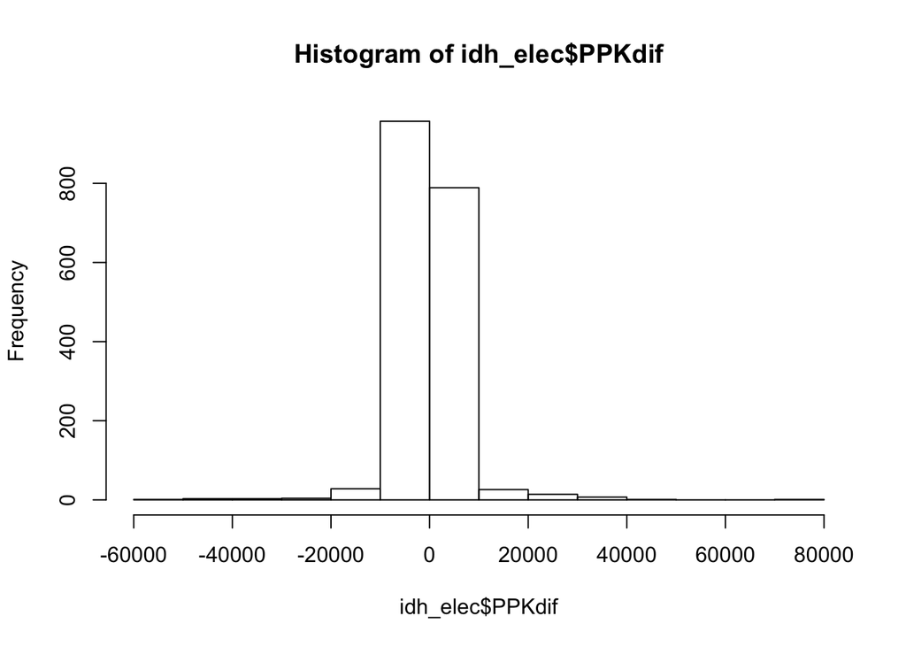

```r
idh_elec$PPKdif=idh_elec$PPK-idh_elec$FP # calculando
hist(idh_elec$PPKdif)  # viendo distribución
```

Tal distribución la podemos recodificar:

```r
idh_elec$PPKdif_O=ifelse(idh_elec$PPKdif==0,3,
                         ifelse(idh_elec$PPKdif<0,2,4))

idh_elec$PPKdif_O=ifelse(idh_elec$PPKdif<(-5000),1,idh_elec$PPKdif_O)
idh_elec$PPKdif_O=ifelse(idh_elec$PPKdif>5000,5,idh_elec$PPKdif_O)

# eso nos da:
table(idh_elec$PPKdif_O)
```

```
##
##   1   2   3   4   5
##  74 919   3 769  69
```

Démosle formato a esa variable:

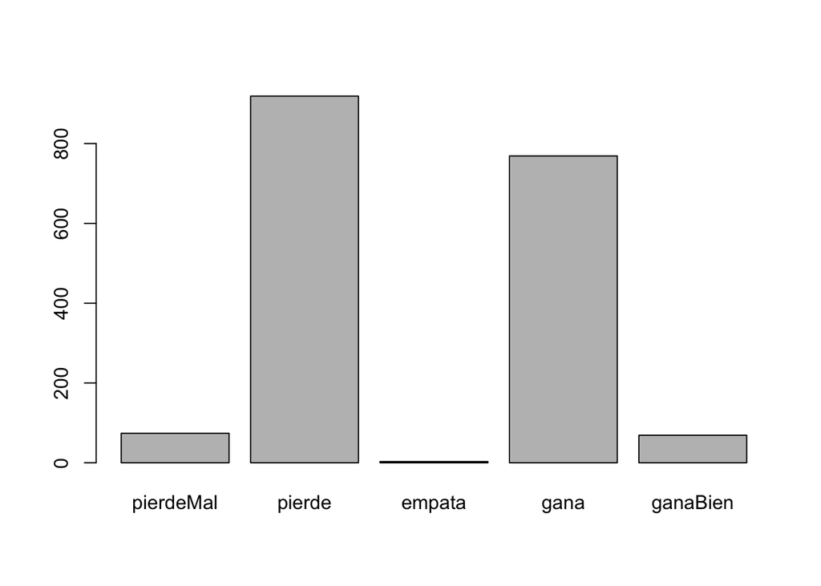

```r
theLevels=c(1,2,3,4,5)
theLabels=c('pierdeMal','pierde','empata','gana','ganaBien')
idh_elec$PPKdif_O=factor(idh_elec$PPKdif_O,
                         levels=theLevels,
                         labels = theLabels,
                         ordered=T)

# visualizando:
barplot(table(idh_elec$PPKdif_O))
```

Como antes, creemos un subconjunto de datos:

```r
test4=idh_elec[,c('PPKdif_O','esperanza','secundaria','tiempoedu','percapitaf')]
```

Teniendo a la variable ordinal como la *Y*, veamos que sucede:

```r
library(ordinal)
modelOrdi <- clm(PPKdif_O ~ ., data=test4)
summary(modelOrdi)
```

```
## formula: PPKdif_O ~ esperanza + secundaria + tiempoedu + percapitaf
## data:    test4
##
##  link  threshold nobs logLik   AIC     niter max.grad cond.H
##  logit flexible  1834 -1757.46 3530.92 10(4) 1.22e-10 1.6e+08
##
## Coefficients:
##              Estimate Std. Error z value Pr(>|z|)
## esperanza  -0.0540723  0.0090402  -5.981 2.21e-09 ***
## secundaria  0.0108766  0.0030684   3.545 0.000393 ***
## tiempoedu  -0.0611045  0.0468912  -1.303 0.192537
## percapitaf  0.0007505  0.0003041   2.468 0.013587 *
## ---
## Signif. codes:  0 '***' 0.001 '**' 0.01 '*' 0.05 '.' 0.1 ' ' 1
##
## Threshold coefficients:
##                  Estimate Std. Error z value
## pierdeMal|pierde  -6.7835     0.6676 -10.161
## pierde|empata     -3.4009     0.6499  -5.233
## empata|gana       -3.3941     0.6498  -5.223
## gana|ganaBien     -0.2646     0.6527  -0.405
```

Con:

```r
100*(exp(modelOrdi$beta)-1)
```

```
##   esperanza  secundaria   tiempoedu  percapitaf
## -5.26363729  1.09359303 -5.92750251  0.07508091
```

```r
test4s=test4
test4s[,c(2:5)]=scale(test4s[,c(2:5)])

## usando normalización
modelOrdi_scaled <- update(modelOrdi,data=test4s)
summary(modelOrdi_scaled)
```

```
## formula: PPKdif_O ~ esperanza + secundaria + tiempoedu + percapitaf
## data:    test4s
##
##  link  threshold nobs logLik   AIC     niter max.grad cond.H
##  logit flexible  1834 -1757.46 3530.92 9(4)  6.73e-07 2.1e+03
##
## Coefficients:
##            Estimate Std. Error z value Pr(>|z|)
## esperanza  -0.28619    0.04785  -5.981 2.21e-09 ***
## secundaria  0.24569    0.06931   3.545 0.000393 ***
## tiempoedu  -0.12720    0.09761  -1.303 0.192537
## percapitaf  0.19591    0.07938   2.468 0.013587 *
## ---
## Signif. codes:  0 '***' 0.001 '**' 0.01 '*' 0.05 '.' 0.1 ' ' 1
##
## Threshold coefficients:
##                  Estimate Std. Error z value
## pierdeMal|pierde -3.22803    0.11940 -27.036
## pierde|empata     0.15464    0.04785   3.232
## empata|gana       0.16141    0.04786   3.372
## gana|ganaBien     3.29089    0.12344  26.659
```

```r
100*(exp(modelOrdi_scaled$beta)-1)
```

```
##  esperanza secundaria  tiempoedu percapitaf
##  -24.88832   27.84984  -11.94393   21.64177
```

Finalmente, veamos esta otra data.

```r
library(openxlsx)
idhName='idh_elect_Prov_06.xlsx'
idhPath=file.path(folder,idhName)
idhEl06=read.xlsx(idhPath)
str(idhEl06)
```

```
## 'data.frame':    194 obs. of  29 variables:
##  $ ubiReg                                     : chr  "010000" "010000" "010000" "010000" ...
##  $ ubiPro                                     : chr  "010200" "010300" "010100" "010400" ...
##  $ reg                                        : chr  "AMAZONAS" "AMAZONAS" "AMAZONAS" "AMAZONAS" ...
##  $ pro                                        : chr  "BAGUA" "BONGARA" "CHACHAPOYAS" "CONDORCANQUI" ...
##  $ espvida                                    : num  73.6 72.2 72.4 70.1 71.3 ...
##  $ secun                                      : num  35.91 21.87 21.59 7.48 26.05 ...
##  $ tiempoedu                                  : num  5.83 5.57 5.42 5.14 5.04 ...
##  $ ingrefami                                  : num  223 235 225 140 211 ...
##  $ ALIANZA.PARA.EL.PROGRESO                   : num  202 103 141 543 180 50 233 22 21 11 ...
##  $ ALIANZA.POR.EL.FUTURO                      : num  3064 1788 1610 1173 1706 ...
##  $ AVANZA.PAIS.-.PARTIDO.DE.INTEGRACION.SOCIAL: num  87 52 39 14 139 14 168 11 21 11 ...
##  $ CON.FUERZA.PERU                            : num  42 13 50 12 24 20 43 13 11 4 ...
##  $ CONCERTACION.DESCENTRALISTA                : num  42 17 58 7 43 9 91 27 9 12 ...
##  $ FRENTE.DE.CENTRO                           : num  2912 266 1489 1599 532 ...
##  $ FUERZA.DEMOCRATICA                         : num  218 17 26 224 65 17 59 13 18 92 ...
##  $ MOVIMIENTO.NUEVA.IZQUIERDA                 : num  91 44 66 403 38 30 258 12 12 74 ...
##  $ PARTIDO.APRISTA.PERUANO                    : num  5255 2130 4884 253 2794 ...
##  $ PARTIDO.JUSTICIA.NACIONAL                  : num  126 31 48 36 60 26 203 12 21 21 ...
##  $ PARTIDO.RECONSTRUCCION.DEMOCRATICA         : num  42 18 21 14 14 11 53 6 16 9 ...
##  $ PARTIDO.RENACIMIENTO.ANDINO                : num  13 7 55 6 12 6 25 8 21 6 ...
##  $ PARTIDO.SOCIALISTA                         : num  73 18 87 23 36 13 42 19 11 11 ...
##  $ PERU.AHORA                                 : num  202 21 8 5 6 3 18 4 5 3 ...
##  $ PROGRESEMOS.PERU                           : num  22 6 13 7 11 13 25 3 8 7 ...
##  $ RESTAURACION.NACIONAL                      : num  1705 465 439 215 547 ...
##  $ RESURGIMIENTO.PERUANO                      : num  50 22 27 19 34 32 62 4 11 6 ...
##  $ UNIDAD.NACIONAL                            : num  2235 1049 3671 897 2498 ...
##  $ UNION.POR.EL.PERU                          : num  8056 2884 6235 3124 4706 ...
##  $ Y.SE.LLAMA.PERU                            : num  11 6 11 11 12 5 17 3 10 7 ...
##  $ GANADOR                                    : chr  "UNION POR EL PERU" "UNION POR EL PERU" "UNION POR EL PERU" "UNION POR EL PERU" ...
```

La data nos muestra la votación que obtuvieron a nivel de provincia cada partido que participó en las elecciones del 2006. Además muestra los componentes del IDH para el 2007. Hay una columna al final, GANADOR, que se comporta así:

```r
table(as.factor(idhEl06$GANADOR))
```

```
##
##   ALIANZA POR EL FUTURO PARTIDO APRISTA PERUANO   RESTAURACION NACIONAL
##                       3                      39                       1
##         UNIDAD NACIONAL       UNION POR EL PERU
##                       5                     146
```

Queremos saber qué componente del IDH favorece o no a un partido en relación al ganador al Partido de Humala. Sigamos los pasos:

1. Declaremos a nuestra *Y* como factor:

```r
idhEl06$GANADOR=as.factor(idhEl06$GANADOR)
```

2. Indiquemos cual es la variable de referencia:

```r
idhEl06$GANADOR = relevel(idhEl06$GANADOR, ref = "UNION POR EL PERU")
```

3. Creemos el subconjunto:

```r
test5=idhEl06[,c(5:8,29)]
```

4. Corramos el modelo

```r
library(nnet)
modelMultinom=multinom(GANADOR ~ ., data=test5)
summary(modelMultinom)
```

```
## Call:
## multinom(formula = GANADOR ~ ., data = test5)
##
## Coefficients:
##                         (Intercept)    espvida       secun  tiempoedu
## ALIANZA POR EL FUTURO    -18.594505  0.2557463 -0.10422364 -0.7003119
## PARTIDO APRISTA PERUANO  -24.063750  0.3070305 -0.01575202 -0.2207953
## RESTAURACION NACIONAL      6.052713 -0.3478699 -0.30919748  5.7330506
## UNIDAD NACIONAL          -29.678640  0.3184084 -0.10746502  0.1248577
##                           ingrefami
## ALIANZA POR EL FUTURO    0.01868934
## PARTIDO APRISTA PERUANO  0.01186252
## RESTAURACION NACIONAL   -0.07715049
## UNIDAD NACIONAL          0.02721706
##
## Std. Errors:
##                         (Intercept)    espvida      secun tiempoedu
## ALIANZA POR EL FUTURO   0.004612537 0.04270843 0.08207165 0.9327789
## PARTIDO APRISTA PERUANO 0.017024621 0.01269965 0.02177590 0.3163284
## RESTAURACION NACIONAL   0.055664247 0.23829310 0.29065066 5.6458776
## UNIDAD NACIONAL         0.005406955 0.03644700 0.06039959 0.8038088
##                           ingrefami
## ALIANZA POR EL FUTURO   0.022377166
## PARTIDO APRISTA PERUANO 0.005210007
## RESTAURACION NACIONAL   0.092578734
## UNIDAD NACIONAL         0.012982712
##
## Residual Deviance: 222.8956
## AIC: 262.8956
```

Todos los resultados se comparan con Humala. Por ejemplo, cada vez que haya un valor negativo, eso indica que el aumento del valor de esa variable del IDH aumenta la probabilidad del voto hacia Humala y no hacia el partido de esa fila. Si fuera positivo, es al revés.

Claro, no todos los coeficientes son significativos, pero eso no ha sido reportado. Aqui los calculamos:

```r
z <- summary(modelMultinom)$coefficients/summary(modelMultinom)$standard.errors
p <- (1 - pnorm(abs(z), 0, 1)) * 2
p
```

```
##                         (Intercept)      espvida      secun tiempoedu
## ALIANZA POR EL FUTURO             0 2.121860e-09 0.20411655 0.4527849
## PARTIDO APRISTA PERUANO           0 0.000000e+00 0.46945278 0.4851810
## RESTAURACION NACIONAL             0 1.443339e-01 0.28741417 0.3098961
## UNIDAD NACIONAL                   0 0.000000e+00 0.07520138 0.8765592
##                          ingrefami
## ALIANZA POR EL FUTURO   0.40360679
## PARTIDO APRISTA PERUANO 0.02279387
## RESTAURACION NACIONAL   0.40464735
## UNIDAD NACIONAL         0.03604603
```

## REVISAR

La última data que hemos visto, se creó de esta manera:

1. Datos de los resultados de las elecciones:

```r
library(openxlsx)

fileName='eg2006_r1.xlsx'
fileToRead=file.path(folder,fileName)
data06=read.xlsx(fileToRead)
head(data06)
```

```
##   ubiReg          reg ubiPro           pro                    parti votos
## 1 030000     APURIMAC 030100       ABANCAY ALIANZA PARA EL PROGRESO   320
## 2 080000 HUANCAVELICA 080200      ACOBAMBA ALIANZA PARA EL PROGRESO    71
## 3 070000        CUSCO 070200       ACOMAYO ALIANZA PARA EL PROGRESO    16
## 4 020000       ANCASH 020200          AIJA ALIANZA PARA EL PROGRESO    22
## 5 940000       EUROPA 940200      ALEMANIA ALIANZA PARA EL PROGRESO     1
## 6 150000       LORETO 150200 ALTO AMAZONAS ALIANZA PARA EL PROGRESO   271
```

Viendo estructura:

```r
str(data06)
```

```
## 'data.frame':    5360 obs. of  6 variables:
##  $ ubiReg: chr  "030000" "080000" "070000" "020000" ...
##  $ reg   : chr  "APURIMAC" "HUANCAVELICA" "CUSCO" "ANCASH" ...
##  $ ubiPro: chr  "030100" "080200" "070200" "020200" ...
##  $ pro   : chr  "ABANCAY" "ACOBAMBA" "ACOMAYO" "AIJA" ...
##  $ parti : chr  "ALIANZA PARA EL PROGRESO" "ALIANZA PARA EL PROGRESO" "ALIANZA PARA EL PROGRESO" "ALIANZA PARA EL PROGRESO" ...
##  $ votos : num  320 71 16 22 1 271 103 133 81 84 ...
```

Los partidos están en una columna, separemoslos:

```r
data06W <- reshape(data06,
                       idvar = c("ubiReg","reg",'ubiPro','pro'),
                       timevar = "parti", direction = "wide")
head(data06W)
```

```
##   ubiReg          reg ubiPro           pro votos.ALIANZA PARA EL PROGRESO
## 1 030000     APURIMAC 030100       ABANCAY                            320
## 2 080000 HUANCAVELICA 080200      ACOBAMBA                             71
## 3 070000        CUSCO 070200       ACOMAYO                             16
## 4 020000       ANCASH 020200          AIJA                             22
## 5 940000       EUROPA 940200      ALEMANIA                              1
## 6 150000       LORETO 150200 ALTO AMAZONAS                            271
##   votos.ALIANZA POR EL FUTURO
## 1                        1584
## 2                        2122
## 3                         127
## 4                         360
## 5                          95
## 6                         667
##   votos.AVANZA PAIS - PARTIDO DE INTEGRACION SOCIAL votos.CON FUERZA PERU
```

[output cut: 62 more lines]

Eliminemos palabra ‘voto.’:

```r
names(data06W)=gsub("votos.", "", names(data06W))
```

Calculemos ganador por locacion:

```r
data06W$GANADOR=colnames(data06W[,-c(1:4)])[max.col(data06W[,-c(1:4)])]
```

Así va:

```r
head(data06W)
```

```
##   ubiReg          reg ubiPro           pro ALIANZA PARA EL PROGRESO
## 1 030000     APURIMAC 030100       ABANCAY                      320
## 2 080000 HUANCAVELICA 080200      ACOBAMBA                       71
## 3 070000        CUSCO 070200       ACOMAYO                       16
## 4 020000       ANCASH 020200          AIJA                       22
## 5 940000       EUROPA 940200      ALEMANIA                        1
## 6 150000       LORETO 150200 ALTO AMAZONAS                      271
##   ALIANZA POR EL FUTURO AVANZA PAIS - PARTIDO DE INTEGRACION SOCIAL
## 1                  1584                                          82
## 2                  2122                                          49
## 3                   127                                          11
## 4                   360                                          11
## 5                    95                                          11
## 6                   667                                          37
##   CON FUERZA PERU CONCERTACION DESCENTRALISTA FRENTE DE CENTRO
```

[output cut: 41 more lines]

Traigamos la data de IDH 2007:

```r
library(openxlsx)
folder='data'
fileName='idhPeru.xlsx'
fileToRead=file.path(folder,fileName)
idh=read.xlsx(fileToRead,sheet = "IDH 2007",
              startRow = 3,
              skipEmptyRows = T)
head(idh)
```

```
##   Ubigeo.2010 DEPARTAMENTO           X3  Población      X5
## 1        <NA>         <NA>    Provincia       <NA>    <NA>
## 2        <NA>         <NA>     Distrito habitantes ranking
## 3      000000     PERÚ  a/         <NA>   27428615    <NA>
## 4      010000     AMAZONAS         <NA>     375993      19
## 5      010100         <NA>  Chachapoyas      49700     117
## 6      010101            1 Chachapoyas       23939     212
##   Índice.de.Desarrollo.Humano      X7 Esperanza.de.vida.al.nacer      X9
## 1                        <NA>    <NA>                       <NA>    <NA>
## 2                         IDH ranking                       años ranking
## 3         0.39524678859594503    <NA>         73.069999999999993    <NA>
## 4         0.28111341224992165      21         72.400000000000006      10
## 5          0.3335262337832664      55         72.489999999999995      68
## 6         0.41684088314060092     138                      72.77     526
##   Población.con.Educ..secundaria.completa     X11
```

[output cut: 20 more lines]

Quedarse sin las tres primeras:

```r
idh=tail(idh,-3)
head(idh)
```

```
##   Ubigeo.2010 DEPARTAMENTO           X3 Población   X5
## 4      010000     AMAZONAS         <NA>    375993   19
## 5      010100         <NA>  Chachapoyas     49700  117
## 6      010101            1 Chachapoyas      23939  212
## 7      010102            2 Asuncion           289 1823
## 8      010103            3    Balsas         1401 1505
## 9      010104            4      Cheto         582 1766
##   Índice.de.Desarrollo.Humano   X7 Esperanza.de.vida.al.nacer  X9
## 4         0.28111341224992165   21         72.400000000000006  10
## 5          0.3335262337832664   55         72.489999999999995  68
## 6         0.41684088314060092  138                      72.77 526
## 7         0.13383302794807134 1805                      72.77 535
## 8         0.21666799717133389 1266                      72.25 697
## 9         0.27070944857048262  773                      72.77 528
##   Población.con.Educ..secundaria.completa  X11
```

[output cut: 20 more lines]

Ver parte inferior:

```r
tail(idh,10)
```

```
##                                                                                                                                                                                                             Ubigeo.2010
## 2054                                                                                                                                                                                                             250302
## 2055                                                                                                                                                                                                             250303
## 2056                                                                                                                                                                                                             250400
## 2057                                                                                                                                                                                                             250401
## 2058 a/ Incluye las cifras estimadas del distrito de Carmen Alto en la provincia de Huamanga, departamento de Ayacucho, donde. Autoridades locales no permitieron la ejecución del Censo de Población y Vivienda 2007.
## 2059                                                                                                       1/ Cifras estimadas. Autoridades locales no permitieron la ejecución del Censo de Población y Vivienda 2007.
## 2060                                                                                                 2/ Incluye a la población ubicada en área temporal por límites de fronteras de los distritos de Pangoa y Mazamari.
## 2061                                                                                                                                                                                    3/ Provincias de Lima y Callao.
## 2062                                                                                                                                                      Fuente: INEI. Censo de Población y Vivienda 2007. ENAHO 2007.
## 2063                                                                                                                                                                                            Elaboración: PNUD-Perú.
##      DEPARTAMENTO         X3 Población   X5 Índice.de.Desarrollo.Humano
## 2054            2 Irazola        18910  261         0.27138930540286793
## 2055            3 Curimana        6047  738         0.24950352020542488
## 2056         <NA>      Purús      3746  195         0.24279243122847766
```

[output cut: 51 more lines]

Eliminar ultimas seis filas:

```r
idh=head(idh,-6)
tail(idh)
```

```
##      Ubigeo.2010 DEPARTAMENTO            X3 Población   X5
## 2052      250300         <NA>    Padre Abad     50590  114
## 2053      250301            1 Padre Abad        25633  196
## 2054      250302            2    Irazola        18910  261
## 2055      250303            3    Curimana        6047  738
## 2056      250400         <NA>         Purús      3746  195
## 2057      250401            1        Purus       3746 1014
##      Índice.de.Desarrollo.Humano   X7 Esperanza.de.vida.al.nacer   X9
## 2052          0.3084834071065059   70                      74.98   23
## 2053         0.33711189469947689  402                       75.2  177
## 2054         0.27138930540286793  770                       74.8  225
## 2055         0.24950352020542488  942                      74.69  239
## 2056         0.24279243122847766  133                      69.33  160
## 2057         0.24279243122847766 1003                      69.33 1551
##      Población.con.Educ..secundaria.completa  X11
```

[output cut: 20 more lines]

Eliminar columnas innecesarias (rankings):

```r
names(idh)
```

```
##  [1] "Ubigeo.2010"
##  [2] "DEPARTAMENTO"
##  [3] "X3"
##  [4] "Población"
##  [5] "X5"
##  [6] "Índice.de.Desarrollo.Humano"
##  [7] "X7"
##  [8] "Esperanza.de.vida.al.nacer"
##  [9] "X9"
## [10] "Población.con.Educ..secundaria.completa"
## [11] "X11"
## [12] "Años.de.educación.(Poblac..25.y.más)"
## [13] "X13"
## [14] "Ingreso.familiar.per.cápita"
## [15] "X15"
```

En *X3* está el título del distrito, ese no se elimina; pero sí todos los demas que comienzan en ‘X’:

```r
# eliminando por posicion:
idh=idh[,-c(seq(5,15,2))]
names(idh)
```

```
## [1] "Ubigeo.2010"
## [2] "DEPARTAMENTO"
## [3] "X3"
## [4] "Población"
## [5] "Índice.de.Desarrollo.Humano"
## [6] "Esperanza.de.vida.al.nacer"
## [7] "Población.con.Educ..secundaria.completa"
## [8] "Años.de.educación.(Poblac..25.y.más)"
## [9] "Ingreso.familiar.per.cápita"
```

Podemos renombrar:

```r
nuevos=c('ubiDis','distrito','pob','idh','espvida','secun','tiempoedu','ingrefami')
names(idh)[c(1,3:9)]=nuevos

#ver
names(idh)
```

```
## [1] "ubiDis"       "DEPARTAMENTO" "distrito"     "pob"
## [5] "idh"          "espvida"      "secun"        "tiempoedu"
## [9] "ingrefami"
```

Ahora crear subconjuntos:

1. De distritos. Deben ser las filas con datos completos en cada celda:

```r
distritos=idh[complete.cases(idh),]
```

2. Regiones. Nos llevamos las tres primeras columnas:

```r
DepsProvs=idh[,c(1:3)]
head(DepsProvs)
```

```
##   ubiDis DEPARTAMENTO     distrito
## 4 010000     AMAZONAS         <NA>
## 5 010100         <NA>  Chachapoyas
## 6 010101            1 Chachapoyas
## 7 010102            2 Asuncion
## 8 010103            3    Balsas
## 9 010104            4      Cheto
```

Tal que las primeras 2 columnas esten completas y la ultima este ausente (missing):

```r
regiones=DepsProvs[complete.cases(DepsProvs[,c(1,2)]) & is.na(DepsProvs[,3]),]
```

3. Provincias. Tal que la primera y la tercera columnas esten completas y la segunda este ausente (missing):

```r
provincias=DepsProvs[complete.cases(DepsProvs[,c(1,3)]) & is.na(DepsProvs[,2]),]
```

Los datos de regiones y provincias tienen una columna con missing:

```r
head(provincias)
```

```
##    ubiDis DEPARTAMENTO             distrito
## 5  010100         <NA>          Chachapoyas
## 27 010200         <NA>                Bagua
## 33 010300         <NA>              Bongará
## 46 010400         <NA>         Condorcanqui
## 50 010500         <NA>                 Luya
## 74 010600         <NA> Rodríguez de Mendoza
```

```r
head(regiones)
```

```
##     ubiDis DEPARTAMENTO distrito
## 4   010000     AMAZONAS     <NA>
## 95  020000       ANCASH     <NA>
## 282 030000     APURÍMAC     <NA>
## 370 040000     AREQUIPA     <NA>
## 488 050000     AYACUCHO     <NA>
## 611 060000    CAJAMARCA     <NA>
```

Esas columnas se eliminan:

```r
regiones$distrito=NULL
provincias$DEPARTAMENTO=NULL
```

Aqui debemos renombrar:

```r
names(regiones)=c('ubiReg','reg')
names(provincias)=c('ubiPro','pro')
```

Estos dos data frames están listos.

4. Hay que preparar las columnas que faltan en la data de distritos:

```r
distritos$ubiReg=paste0(substr(distritos$ubiDis,1,2),'0000')
distritos$ubiPro=paste0(substr(distritos$ubiDis,1,4),'00')
```

5. Ya estamos listos para el merge:

```r
#añado nombre de region
distritos=merge(distritos,regiones,all.x = T)

#añado nombre de provincia
distritos=merge(distritos,provincias,all.x = T)
```

Que tenemos:

```r
head(distritos)
```

```
##   ubiPro ubiReg ubiDis DEPARTAMENTO     distrito   pob                 idh
## 1 010100 010000 010103            3    Balsas     1401 0.21666799717133389
## 2 010100 010000 010104            4      Cheto     582 0.27070944857048262
## 3 010100 010000 010101            1 Chachapoyas  23939 0.41684088314060092
## 4 010100 010000 010102            2 Asuncion       289 0.13383302794807134
## 5 010100 010000 010111           11     Levanto    945 0.18102923604975515
## 6 010100 010000 010112           12  Magdalena     880 0.29849041227290707
##              espvida               secun          tiempoedu
## 1              72.25  14.486443165814336 4.8911195512820509
## 2              72.77  44.626220621395959 4.7150411184210528
## 3              72.77  62.517346162406731 9.5892634051688539
## 4              72.77 0.76151448484326145 5.9888910614525139
## 5 72.489999999999995  6.2323880422365834 4.3539377637130805
## 6 72.430000000000007  36.754594398759203 5.8512622767857136
##            ingrefami      reg         pro
## 1 214.28999510036576 AMAZONAS Chachapoyas
## 2  237.9317267965593 AMAZONAS Chachapoyas
## 3 417.93015249705172 AMAZONAS Chachapoyas
## 4 191.58797194417036 AMAZONAS Chachapoyas
## 5 209.51145315818286 AMAZONAS Chachapoyas
## 6 291.09398714244372 AMAZONAS Chachapoyas
```

```r
str(distritos)
```

```
## 'data.frame':    1833 obs. of  13 variables:
##  $ ubiPro      : chr  "010100" "010100" "010100" "010100" ...
##  $ ubiReg      : chr  "010000" "010000" "010000" "010000" ...
##  $ ubiDis      : chr  "010103" "010104" "010101" "010102" ...
##  $ DEPARTAMENTO: chr  "3" "4" "1" "2" ...
##  $ distrito    : chr  "Balsas   " "Cheto  " "Chachapoyas " "Asuncion    " ...
##  $ pob         : chr  "1401" "582" "23939" "289" ...
##  $ idh         : chr  "0.21666799717133389" "0.27070944857048262" "0.41684088314060092" "0.13383302794807134" ...
##  $ espvida     : chr  "72.25" "72.77" "72.77" "72.77" ...
##  $ secun       : chr  "14.486443165814336" "44.626220621395959" "62.517346162406731" "0.76151448484326145" ...
##  $ tiempoedu   : chr  "4.8911195512820509" "4.7150411184210528" "9.5892634051688539" "5.9888910614525139" ...
##  $ ingrefami   : chr  "214.28999510036576" "237.9317267965593" "417.93015249705172" "191.58797194417036" ...
##  $ reg         : chr  "AMAZONAS" "AMAZONAS" "AMAZONAS" "AMAZONAS" ...
##  $ pro         : chr  "Chachapoyas" "Chachapoyas" "Chachapoyas" "Chachapoyas" ...
```

Algunos retoques son MUY necesarios:

- Recodificar columna *DEPARTAMENTO* y renombrarla:

```r
#tener en cuenta que es 'character'
distritos$DEPARTAMENTO=ifelse(distritos$DEPARTAMENTO=='1',1,0)
names(distritos)[names(distritos)=="DEPARTAMENTO"] <- "ciudadCapital"
```

- Dar un orden adecuado a las columnas:

```r
distritos=distritos[,c(2,1,3,12,13,5,6:11,4)]
head(distritos)
```

```
##   ubiReg ubiPro ubiDis      reg         pro     distrito   pob
## 1 010000 010100 010103 AMAZONAS Chachapoyas    Balsas     1401
## 2 010000 010100 010104 AMAZONAS Chachapoyas      Cheto     582
## 3 010000 010100 010101 AMAZONAS Chachapoyas Chachapoyas  23939
## 4 010000 010100 010102 AMAZONAS Chachapoyas Asuncion       289
## 5 010000 010100 010111 AMAZONAS Chachapoyas     Levanto    945
## 6 010000 010100 010112 AMAZONAS Chachapoyas  Magdalena     880
##                   idh            espvida               secun
## 1 0.21666799717133389              72.25  14.486443165814336
## 2 0.27070944857048262              72.77  44.626220621395959
## 3 0.41684088314060092              72.77  62.517346162406731
## 4 0.13383302794807134              72.77 0.76151448484326145
## 5 0.18102923604975515 72.489999999999995  6.2323880422365834
## 6 0.29849041227290707 72.430000000000007  36.754594398759203
##            tiempoedu          ingrefami ciudadCapital
## 1 4.8911195512820509 214.28999510036576             0
## 2 4.7150411184210528  237.9317267965593             0
## 3 9.5892634051688539 417.93015249705172             1
## 4 5.9888910614525139 191.58797194417036             0
## 5 4.3539377637130805 209.51145315818286             0
## 6 5.8512622767857136 291.09398714244372             0
```

Transformar en numero algunas columnas:

```r
distritos[,c(7:12)]=lapply(distritos[,c(7:12)],as.numeric)
```

Nos quedamos con los componentes:

```r
# sin lo que se necesita:
componentsDis=distritos[,-c(7,8,13)]
```

Y los agregamos a nivel provincia:

```r
idhProv=aggregate(cbind(espvida,secun,tiempoedu,ingrefami) ~ ubiReg+ubiPro+reg+pro, data=componentsDis,FUN=mean)
head(idhProv)
```

```
##   ubiReg ubiPro          reg           pro  espvida    secun tiempoedu
## 1 030000 030100     APURÍMAC       Abancay 73.01333 47.27998  5.767101
## 2 090000 090200 HUANCAVELICA      Acobamba 71.41125 34.19573  4.620941
## 3 080000 080200        CUSCO       Acomayo 66.15143 39.30471  4.707360
## 4 020000 020200       ANCASH          Aija 66.65400 34.36151  6.913321
## 5 160000 160200       LORETO Alto Amazonas 70.26167 17.51263  5.285653
## 6 100000 100200      HUÁNUCO          Ambo 72.76000 31.81701  4.375192
##   ingrefami
## 1  198.4380
## 2  118.2181
## 3  143.7702
## 4  202.7716
## 5  163.3549
## 6  178.3872
```

Nótese que hay símbolos propios del español, es importante aqui cambiar esto.

```r
library(stringi)
idhProv$pro=toupper(stri_trans_general(idhProv$pro,"Latin-ASCII"))
idhProv$reg=toupper(stri_trans_general(idhProv$reg,"Latin-ASCII"))
head(idhProv)
```

```
##   ubiReg ubiPro          reg           pro  espvida    secun tiempoedu
## 1 030000 030100     APURIMAC       ABANCAY 73.01333 47.27998  5.767101
## 2 090000 090200 HUANCAVELICA      ACOBAMBA 71.41125 34.19573  4.620941
## 3 080000 080200        CUSCO       ACOMAYO 66.15143 39.30471  4.707360
## 4 020000 020200       ANCASH          AIJA 66.65400 34.36151  6.913321
## 5 160000 160200       LORETO ALTO AMAZONAS 70.26167 17.51263  5.285653
## 6 100000 100200      HUANUCO          AMBO 72.76000 31.81701  4.375192
##   ingrefami
## 1  198.4380
## 2  118.2181
## 3  143.7702
## 4  202.7716
## 5  163.3549
## 6  178.3872
```

Vemos que *data06W* no tiene ese problema, pero porsiacaso también la normalizamos:

```r
data06W$pro=toupper(stri_trans_general(data06W$pro,"Latin-ASCII"))
data06W$reg=toupper(stri_trans_general(data06W$reg,"Latin-ASCII"))
```

Hemos hecho esto para tener más opciones para hacer el *merge* de ambos documentos.

Aquí veremos un problema con ambas fuentes de datos:

```r
head(merge(idhProv,data06W,
        by='ubiPro',
        all.x = T))[,c(1,4,11)]
```

```
##   ubiPro                pro.x                pro.y
## 1 010100          CHACHAPOYAS          CHACHAPOYAS
## 2 010200                BAGUA                BAGUA
## 3 010300              BONGARA              BONGARA
## 4 010400         CONDORCANQUI                 LUYA
## 5 010500                 LUYA RODRIGUEZ DE MENDOZA
## 6 010600 RODRIGUEZ DE MENDOZA         CONDORCANQUI
```

Desafortunadamente, los ubigeos no son los mismos entre JNE (elecciones) y el INEI (usado por PNUD). Trabajemos así (por ahora).

Como no podemos usar los ubigeos, lo que nos queda es hacerlo con los nombres. Para ello tenemos que concatenar nombre de region y provincia, pues puede haber nombres repetidos de provincias si se las toma solas.

```r
idhProv$key=paste0(idhProv$reg,idhProv$pro)
data06W$key=paste0(data06W$reg,data06W$pro)
```

Veamos el merge:

```r
head(merge(idhProv,data06W,
        by='key',
        all.x = T),10)[,c(4,5,11,13)]
```

```
##       reg.x                pro.x    reg.y                pro.y
## 1  AMAZONAS                BAGUA AMAZONAS                BAGUA
## 2  AMAZONAS              BONGARA AMAZONAS              BONGARA
## 3  AMAZONAS          CHACHAPOYAS AMAZONAS          CHACHAPOYAS
## 4  AMAZONAS         CONDORCANQUI AMAZONAS         CONDORCANQUI
## 5  AMAZONAS                 LUYA AMAZONAS                 LUYA
## 6  AMAZONAS RODRIGUEZ DE MENDOZA AMAZONAS RODRIGUEZ DE MENDOZA
## 7  AMAZONAS            UTCUBAMBA AMAZONAS            UTCUBAMBA
## 8    ANCASH                 AIJA   ANCASH                 AIJA
## 9    ANCASH     ANTONIO RAYMONDI     <NA>                 <NA>
## 10   ANCASH             ASUNCION   ANCASH             ASUNCION
```

Esto esta mejor, pero nótese que hay valores perdidos. Primero hagamos el merge:

```r
# aqui si
idh_elect_Prov_06=merge(idhProv,data06W,by='key',all.x = T)
```

Ahora preocupemosnos de los missing:

```r
idh_elect_Prov_06[!complete.cases(idh_elect_Prov_06),]
```

```
##                        key ubiReg.x ubiPro.x  reg.x             pro.x
## 9   ANCASHANTONIO RAYMONDI   020000   020300 ANCASH  ANTONIO RAYMONDI
## 109         JUNINSATIPO 2/   120000   120600  JUNIN         SATIPO 2/
## 150 PASCODANIEL A. CARRION   190000   190200  PASCO DANIEL A. CARRION
##      espvida    secun tiempoedu ingrefami ubiReg.y reg.y ubiPro.y pro.y
## 9   69.13500 28.94333  5.592158  160.1296     <NA>  <NA>     <NA>  <NA>
## 109 70.89250 38.39157  6.315977  178.1712     <NA>  <NA>     <NA>  <NA>
## 150 69.91625 73.29042  6.872175  155.1548     <NA>  <NA>     <NA>  <NA>
##     ALIANZA PARA EL PROGRESO ALIANZA POR EL FUTURO
## 9                         NA                    NA
## 109                       NA                    NA
## 150                       NA                    NA
##     AVANZA PAIS - PARTIDO DE INTEGRACION SOCIAL CON FUERZA PERU
## 9                                            NA              NA
## 109                                          NA              NA
```

[output cut: 25 more lines]

Cuando ponemos *all.x=T* significa que todas las filas de x, en este caso *idhProv*, se presentarán en el resultado. Es decir, estas son las tres provincias que no se encontraron. Por los nombres, vemos que debemos hacer cambios manuales en la *key*:

Cuáles son los problemas?

```r
idh_elect_Prov_06[!complete.cases(idh_elect_Prov_06),]$pro.x
```

```
## [1] "ANTONIO RAYMONDI"  "SATIPO 2/"         "DANIEL A. CARRION"
```

En qué fila están?

```r
what=idh_elect_Prov_06[!complete.cases(idh_elect_Prov_06),]$pro.x
idhProv[idhProv$pro%in%what,]
```

```
##     ubiReg ubiPro    reg               pro  espvida    secun tiempoedu
## 11  020000 020300 ANCASH  ANTONIO RAYMONDI 69.13500 28.94333  5.592158
## 66  190000 190200  PASCO DANIEL A. CARRION 69.91625 73.29042  6.872175
## 168 120000 120600  JUNIN         SATIPO 2/ 70.89250 38.39157  6.315977
##     ingrefami                    key
## 11   160.1296 ANCASHANTONIO RAYMONDI
## 66   155.1548 PASCODANIEL A. CARRION
## 168  178.1712         JUNINSATIPO 2/
```

Cambiemos:

```r
change=c("ANTONIO RAIMONDI", "DANIEL ALCIDES CARRION","SATIPO")
idhProv[idhProv$pro%in%what,]$pro=change
```

Creemos nueva *key*:

```r
idhProv$key=paste0(idhProv$reg,idhProv$pro)
```

Rehacemos el merge:

```r
idh_elect_Prov_06=merge(idhProv,data06W,by='key',all.x = T)
```

Ya debe estar OK:

```r
idh_elect_Prov_06[!complete.cases(idh_elect_Prov_06),]
```

```
##  [1] key
##  [2] ubiReg.x
##  [3] ubiPro.x
##  [4] reg.x
##  [5] pro.x
##  [6] espvida
##  [7] secun
##  [8] tiempoedu
##  [9] ingrefami
## [10] ubiReg.y
## [11] reg.y
## [12] ubiPro.y
## [13] pro.y
## [14] ALIANZA PARA EL PROGRESO
## [15] ALIANZA POR EL FUTURO
```

[output cut: 20 more lines]

Así es. Qué tenemos?

```r
str(idh_elect_Prov_06)
```

```
## 'data.frame':    194 obs. of  34 variables:
##  $ key                                        : chr  "AMAZONASBAGUA" "AMAZONASBONGARA" "AMAZONASCHACHAPOYAS" "AMAZONASCONDORCANQUI" ...
##  $ ubiReg.x                                   : chr  "010000" "010000" "010000" "010000" ...
##  $ ubiPro.x                                   : chr  "010200" "010300" "010100" "010400" ...
##  $ reg.x                                      : chr  "AMAZONAS" "AMAZONAS" "AMAZONAS" "AMAZONAS" ...
##  $ pro.x                                      : chr  "BAGUA" "BONGARA" "CHACHAPOYAS" "CONDORCANQUI" ...
##  $ espvida                                    : num  73.6 72.2 72.4 70.1 71.3 ...
##  $ secun                                      : num  35.91 21.87 21.59 7.48 26.05 ...
##  $ tiempoedu                                  : num  5.83 5.57 5.42 5.14 5.04 ...
##  $ ingrefami                                  : num  223 235 225 140 211 ...
##  $ ubiReg.y                                   : chr  "010000" "010000" "010000" "010000" ...
##  $ reg.y                                      : chr  "AMAZONAS" "AMAZONAS" "AMAZONAS" "AMAZONAS" ...
##  $ ubiPro.y                                   : chr  "010200" "010300" "010100" "010600" ...
##  $ pro.y                                      : chr  "BAGUA" "BONGARA" "CHACHAPOYAS" "CONDORCANQUI" ...
##  $ ALIANZA PARA EL PROGRESO                   : num  202 103 141 543 180 50 233 22 21 11 ...
```

[output cut: 20 more lines]

Podemos hacer alguna limpieza:

```r
names(idh_elect_Prov_06)=gsub(".x", "", names(idh_elect_Prov_06))
idh_elect_Prov_06=idh_elect_Prov_06[,-c(1,10:13)]
str(idh_elect_Prov_06)
```

```
## 'data.frame':    194 obs. of  29 variables:
##  $ ubiReg                                     : chr  "010000" "010000" "010000" "010000" ...
##  $ ubiPro                                     : chr  "010200" "010300" "010100" "010400" ...
##  $ reg                                        : chr  "AMAZONAS" "AMAZONAS" "AMAZONAS" "AMAZONAS" ...
##  $ pro                                        : chr  "BAGUA" "BONGARA" "CHACHAPOYAS" "CONDORCANQUI" ...
##  $ espvida                                    : num  73.6 72.2 72.4 70.1 71.3 ...
##  $ secun                                      : num  35.91 21.87 21.59 7.48 26.05 ...
##  $ tiempoedu                                  : num  5.83 5.57 5.42 5.14 5.04 ...
##  $ ingrefami                                  : num  223 235 225 140 211 ...
##  $ ALIANZA PARA EL PROGRESO                   : num  202 103 141 543 180 50 233 22 21 11 ...
##  $ ALIANZA POR EL FUTURO                      : num  3064 1788 1610 1173 1706 ...
##  $ AVANZA PAIS - PARTIDO DE INTEGRACION SOCIAL: num  87 52 39 14 139 14 168 11 21 11 ...
##  $ CON FUERZA PERU                            : num  42 13 50 12 24 20 43 13 11 4 ...
##  $ CONCERTACION DESCENTRALISTA                : num  42 17 58 7 43 9 91 27 9 12 ...
##  $ FRENTE DE CENTRO                           : num  2912 266 1489 1599 532 ...
##  $ FUERZA DEMOCRATICA                         : num  218 17 26 224 65 17 59 13 18 92 ...
##  $ MOVIMIENTO NUEVA IZQUIERDA                 : num  91 44 66 403 38 30 258 12 12 74 ...
##  $ PARTIDO APRISTA PERUANO                    : num  5255 2130 4884 253 2794 ...
##  $ PARTIDO JUSTICIA NACIONAL                  : num  126 31 48 36 60 26 203 12 21 21 ...
##  $ PARTIDO RECONSTRUCCION DEMOCRATICA         : num  42 18 21 14 14 11 53 6 16 9 ...
##  $ PARTIDO RENACIMIENTO ANDINO                : num  13 7 55 6 12 6 25 8 21 6 ...
##  $ PARTIDO SOCIALISTA                         : num  73 18 87 23 36 13 42 19 11 11 ...
##  $ PERU AHORA                                 : num  202 21 8 5 6 3 18 4 5 3 ...
##  $ PROGRESEMOS PERU                           : num  22 6 13 7 11 13 25 3 8 7 ...
##  $ RESTAURACION NACIONAL                      : num  1705 465 439 215 547 ...
##  $ RESURGIMIENTO PERUANO                      : num  50 22 27 19 34 32 62 4 11 6 ...
##  $ UNIDAD NACIONAL                            : num  2235 1049 3671 897 2498 ...
##  $ UNION POR EL PERU                          : num  8056 2884 6235 3124 4706 ...
##  $ Y SE LLAMA PERU                            : num  11 6 11 11 12 5 17 3 10 7 ...
##  $ GANADOR                                    : chr  "UNION POR EL PERU" "UNION POR EL PERU" "UNION POR EL PERU" "UNION POR EL PERU" ...
```

Esto lo guardamos, y es el archivo que usaste antes:

```r
##CUIDADO: NO LO EJECUTES SI NO ESTA BIEN LO QUE HAS HECHO!!!
nombreArch='idh_elect_Prov_06.xlsx'
archGuardar=file.path(folder,nombreArch)
write.xlsx(idh_elect_Prov_06,archGuardar)
```

Inicio

#### [VOLVER AL SILABO](https://inteligenciaperu.github.io/Estadistica/)